# 0.ModelingCOVID19

```python
import pandas as pd
import seaborn as sns
from matplotlib import pyplot
from matplotlib import dates as dt
import matplotlib.pyplot as plt
import numpy as np
from datetime import timedelta, date
import datetime
import io
import math
from scipy.integrate import odeint
from sklearn import linear_model
from sklearn.metrics import max_error
pd.set_option('display.max_columns', None)
sns.set(font_scale=1)
```

## UNDERSTANDING THE EVOLUTION AND MODELING

```
 1. Exploratory data analysis
 2. Understanding the first wave with a linear model
     2.1 Building the linear model
     2.2 Plotting results
 3. SIR Model
     3.1 Differential equations for SIR model
     3.2 Estimating parameters
     3.3 Plotting the results for different values of R0.
 4. Conclusions
 5. References
```

## 1. EXPLORATORY DATA ANALYSIS

Now we will use a dataset with more information of the cases of Covid and the evolution in the hospitals. You can find the updated dataset: https://analisi.transparenciacatalunya.cat/Salut/Dades-di-ries-de-COVID-19-per-comarca/c7sd-zy9j

In this new dataset we have:

- Number of daily PCRs.
- Positive tests by a PCR.
- Daily deaths.
- Daily ICU entries.
- Daily general entries in hospitals.

```python
filename = 'data/modeling/per_comarca_612.exc.xlsx'
sep=";"
# Read the data as a dataframe
diaries = pd.read_excel(filename)
diaries = diaries.rename(columns={"EXITUS": "DEFUNCIONS"})
diaries.head(4)
```

|  | NOM | CODI | DATA | SEXE | GRUP_EDAT | RESIDENCIA | CASOS_CONFIRMAT | PCR | INGRESSOS_TOTAL | INGRESSOS_CRITIC | INGRESSATS_TOTAL | INGRESSATS_CRITIC | DEFUNCIONS |
| --- | --- | --- | --- | --- | --- | --- | --- | --- | --- | --- | --- | --- | --- |
| 0 | ALT CAMP | 1 | 2020-03-01 | Dona | Entre 15 i 64 | No | 0 | 0 | 0 | 0 | 0 | 0 | 0 |
| 1 | ALT CAMP | 1 | 2020-03-01 | Dona | Entre 15 i 64 | Si | 0 | 0 | 0 | 0 | 0 | 0 | 0 |
| 2 | ALT CAMP | 1 | 2020-03-01 | Dona | Entre 65 i 74 | No | 0 | 0 | 0 | 0 | 0 | 0 | 0 |
| 3 | ALT CAMP | 1 | 2020-03-01 | Dona | Entre 65 i 74 | Si | 0 | 0 | 0 | 0 | 0 | 0 | 0 |

```python
diaries.info()
```

```
<class 'pandas.core.frame.DataFrame'>
RangeIndex: 173880 entries, 0 to 173879
Data columns (total 13 columns):
 #   Column             Non-Null Count   Dtype
---  ------             --------------   -----
 0   NOM                173880 non-null  object
 1   CODI               173880 non-null  int64
 2   DATA               173880 non-null  datetime64[ns]
 3   SEXE               173880 non-null  object
 4   GRUP_EDAT          173880 non-null  object
 5   RESIDENCIA         173880 non-null  object
 6   CASOS_CONFIRMAT    173880 non-null  int64
 7   PCR                173880 non-null  int64
 8   INGRESSOS_TOTAL    173880 non-null  int64
 9   INGRESSOS_CRITIC   173880 non-null  int64
 10  INGRESSATS_TOTAL   173880 non-null  int64
 11  INGRESSATS_CRITIC  173880 non-null  int64
 12  DEFUNCIONS         173880 non-null  int64
dtypes: datetime64[ns](1), int64(8), object(4)
memory usage: 17.2+ MB
```

```python
diaries.head()
```

|  | NOM | CODI | DATA | SEXE | GRUP_EDAT | RESIDENCIA | CASOS_CONFIRMAT | PCR | INGRESSOS_TOTAL | INGRESSOS_CRITIC | INGRESSATS_TOTAL | INGRESSATS_CRITIC | DEFUNCIONS |
| --- | --- | --- | --- | --- | --- | --- | --- | --- | --- | --- | --- | --- | --- |
| 0 | ALT CAMP | 1 | 2020-03-01 | Dona | Entre 15 i 64 | No | 0 | 0 | 0 | 0 | 0 | 0 | 0 |
| 1 | ALT CAMP | 1 | 2020-03-01 | Dona | Entre 15 i 64 | Si | 0 | 0 | 0 | 0 | 0 | 0 | 0 |
| 2 | ALT CAMP | 1 | 2020-03-01 | Dona | Entre 65 i 74 | No | 0 | 0 | 0 | 0 | 0 | 0 | 0 |
| 3 | ALT CAMP | 1 | 2020-03-01 | Dona | Entre 65 i 74 | Si | 0 | 0 | 0 | 0 | 0 | 0 | 0 |
| 4 | ALT CAMP | 1 | 2020-03-01 | Dona | Majors de 74 | No | 0 | 0 | 0 | 0 | 0 | 0 | 0 |

If we group the data by patients that were living in residences for the elderly, we will see:

- Even though the positive cases in residences represent only a 7%, the death rate goes up to the 46%.

```python
residencia = diaries.groupby(['RESIDENCIA'])['CASOS_CONFIRMAT','PCR','INGRESSOS_TOTAL','INGRESSOS_CRITIC','DEFUNCIONS'].sum()
residencia['%DEFUNCIONS'] = (residencia['DEFUNCIONS'] / residencia['DEFUNCIONS'].sum())*100
residencia['%INGRESSOS CRITICS'] = (residencia['INGRESSOS_CRITIC'] / residencia['INGRESSOS_CRITIC'].sum())*100
residencia['%INGRESSOS TOTAL'] = (residencia['INGRESSOS_TOTAL'] / residencia['INGRESSOS_TOTAL'].sum())*100
residencia['%CASOS CONFIRMATS'] = (residencia['CASOS_CONFIRMAT'] / residencia['CASOS_CONFIRMAT'].sum())*100
residencia
```

| RESIDENCIA | CASOS_CONFIRMAT | PCR | INGRESSOS_TOTAL | INGRESSOS_CRITIC | DEFUNCIONS | %DEFUNCIONS | %INGRESSOS CRITICS | %INGRESSOS TOTAL | %CASOS CONFIRMATS |
| --- | --- | --- | --- | --- | --- | --- | --- | --- | --- |
| No | 288184 | 3499856 | 19640 | 3271 | 8662 | 53.858111 | 97.99281 | 90.732699 | 92.482863 |
| Si | 23424 | 243514 | 2006 | 67 | 7421 | 46.141889 | 2.00719 | 9.267301 | 7.517137 |

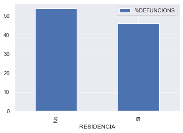

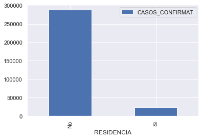

```python
residencia[['%DEFUNCIONS']].plot(kind = 'bar')
plt.show()
residencia[['CASOS_CONFIRMAT']].plot(kind = 'bar')
plt.show()
```

If we now check by range of age, we can say the most affected group were more deaths are detected is in people over 74 years (82%), but almost the 70% of the cases are detected in people between 15 and 64 years.

```python
grup_edat = diaries.groupby(['GRUP_EDAT'])['CASOS_CONFIRMAT','PCR','INGRESSOS_TOTAL','INGRESSOS_CRITIC','DEFUNCIONS'].sum()
grup_edat['% DEFUNCIONS'] = (grup_edat['DEFUNCIONS'] / grup_edat['DEFUNCIONS'].sum())*100
grup_edat['% INGRESSOS CRITICS'] = (grup_edat['INGRESSOS_CRITIC'] / grup_edat['INGRESSOS_CRITIC'].sum())*100
grup_edat['% INGRESSOS TOTAL'] = (grup_edat['INGRESSOS_TOTAL'] / grup_edat['INGRESSOS_TOTAL'].sum())*100
grup_edat['% CASOS CONFIRMATS'] = (grup_edat['CASOS_CONFIRMAT'] / grup_edat['CASOS_CONFIRMAT'].sum())*100
grup_edat.head()
```

| GRUP_EDAT | CASOS_CONFIRMAT | PCR | INGRESSOS_TOTAL | INGRESSOS_CRITIC | DEFUNCIONS | % DEFUNCIONS | % INGRESSOS CRITICS | % INGRESSOS TOTAL | % CASOS CONFIRMATS |
| --- | --- | --- | --- | --- | --- | --- | --- | --- | --- |
| Entre 15 i 64 | 212868 | 2376991 | 9638 | 1734 | 1016 | 6.317229 | 51.947274 | 44.525547 | 68.312752 |
| Entre 65 i 74 | 22363 | 294381 | 3964 | 853 | 1775 | 11.036498 | 25.554224 | 18.312852 | 7.176645 |
| Majors de 74 | 42633 | 505087 | 7821 | 707 | 13289 | 82.627619 | 21.180348 | 36.131387 | 13.681613 |
| Menors de 15 | 33744 | 566911 | 223 | 44 | 3 | 0.018653 | 1.318155 | 1.030213 | 10.828990 |

By waves:

```python
firstwave = diaries.sort_values(by=['DATA'])[:70000]
bydate = firstwave.groupby(['RESIDENCIA'],sort=True)['CASOS_CONFIRMAT','PCR','INGRESSOS_TOTAL','INGRESSOS_CRITIC','INGRESSATS_CRITIC','INGRESSATS_TOTAL','DEFUNCIONS'].sum()
bydate
```

| RESIDENCIA | CASOS_CONFIRMAT | PCR | INGRESSOS_TOTAL | INGRESSOS_CRITIC | INGRESSATS_CRITIC | INGRESSATS_TOTAL | DEFUNCIONS |
| --- | --- | --- | --- | --- | --- | --- | --- |
| No | 44424 | 492134 | 1687 | 218 | 9007 | 33787 | 6261 |
| Si | 14991 | 105096 | 469 | 12 | 225 | 10491 | 6242 |

```python
secondwave = diaries.sort_values(by=['DATA'])[70000:]
secondwave = secondwave.groupby(['RESIDENCIA'],sort=True)['CASOS_CONFIRMAT','PCR','INGRESSOS_TOTAL','INGRESSOS_CRITIC','INGRESSATS_CRITIC','INGRESSATS_TOTAL','DEFUNCIONS'].sum()
secondwave
```

| RESIDENCIA | CASOS_CONFIRMAT | PCR | INGRESSOS_TOTAL | INGRESSOS_CRITIC | INGRESSATS_CRITIC | INGRESSATS_TOTAL | DEFUNCIONS |
| --- | --- | --- | --- | --- | --- | --- | --- |
| No | 243760 | 3007722 | 17953 | 3053 | 31661 | 154939 | 2401 |
| Si | 8433 | 138418 | 1537 | 55 | 379 | 13584 | 1179 |

Now we group by day and see the evolution of the cases, the tests and the deaths.

```python
data = diaries.groupby(['DATA'],sort=True)['CASOS_CONFIRMAT','PCR','INGRESSOS_TOTAL','INGRESSOS_CRITIC','INGRESSATS_CRITIC','INGRESSATS_TOTAL','DEFUNCIONS'].sum()
data = data.reset_index()
data
```

|  | DATA | CASOS_CONFIRMAT | PCR | INGRESSOS_TOTAL | INGRESSOS_CRITIC | INGRESSATS_CRITIC | INGRESSATS_TOTAL | DEFUNCIONS |
| --- | --- | --- | --- | --- | --- | --- | --- | --- |
| 0 | 2020-03-01 | 1 | 20 | 0 | 0 | 0 | 0 | 0 |
| 1 | 2020-03-02 | 4 | 34 | 0 | 0 | 0 | 0 | 0 |
| 2 | 2020-03-03 | 9 | 25 | 0 | 0 | 0 | 0 | 0 |
| 3 | 2020-03-04 | 7 | 29 | 0 | 0 | 0 | 0 | 0 |
| 4 | 2020-03-05 | 18 | 37 | 0 | 0 | 0 | 0 | 0 |
| ... | ... | ... | ... | ... | ... | ... | ... | ... |
| 275 | 2020-12-01 | 1382 | 40517 | 104 | 19 | 364 | 1567 | 48 |
| 276 | 2020-12-02 | 1248 | 43467 | 97 | 25 | 355 | 1495 | 38 |
| 277 | 2020-12-03 | 1076 | 41445 | 98 | 20 | 346 | 1445 | 50 |
| 278 | 2020-12-04 | 878 | 33984 | 91 | 19 | 340 | 1404 | 29 |
| 279 | 2020-12-05 | 264 | 7574 | 0 | 8 | 330 | 1438 | 0 |

280 rows × 8 columns

```python
data.info()
```

```
<class 'pandas.core.frame.DataFrame'>
RangeIndex: 280 entries, 0 to 279
Data columns (total 8 columns):
 #   Column             Non-Null Count  Dtype
---  ------             --------------  -----
 0   DATA               280 non-null    datetime64[ns]
 1   CASOS_CONFIRMAT    280 non-null    int64
 2   PCR                280 non-null    int64
 3   INGRESSOS_TOTAL    280 non-null    int64
 4   INGRESSOS_CRITIC   280 non-null    int64
 5   INGRESSATS_CRITIC  280 non-null    int64
 6   INGRESSATS_TOTAL   280 non-null    int64
 7   DEFUNCIONS         280 non-null    int64
dtypes: datetime64[ns](1), int64(7)
memory usage: 17.6 KB
```

```python
confirmed = data.CASOS_CONFIRMAT.sum()
tingressos = data.INGRESSOS_TOTAL.sum()
uciingressos = data.INGRESSOS_CRITIC.sum()
deaths = data.DEFUNCIONS.sum()
```

```python
print("Total number of confirmed cases: " + str(confirmed))
print("Total number of hospital admissions: " + str(tingressos))
print("Total number of hospital admissions in intensive care units: " + str(uciingressos))
print("Total number of deaths: " + str(deaths))
```

```
Total number of confirmed cases: 311608
Total number of hospital admissions: 21646
Total number of hospital admissions in intensive care units: 3338
Total number of deaths: 16083
```

```python
print("Portion of cases that end up in hospitalization: " + str(tingressos/confirmed))
print("Portion of cases that end up in ICU: " + str(uciingressos/tingressos))
print("Portion of cases that end up in death: " + str(deaths/confirmed))
```

```
Portion of cases that end up in hospitalization: 0.06946548227259891
Portion of cases that end up in ICU: 0.1542086297699344
Portion of cases that end up in death: 0.05161292393006598
```

If we plot the 'CASOS_CONFIRMAT' we can see that the distribution is irregular. To soften it we apply a 7 days mean. We will also do it with the rest of the variables.

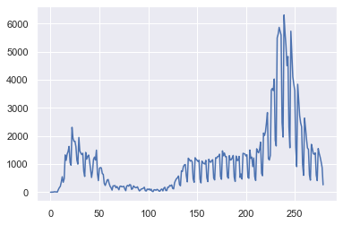

```python
data['CASOS_CONFIRMAT'].plot()
plt.show()
```

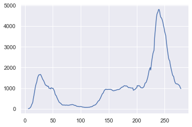

```python
rolling_average_days = 7
data['CASOS_ROLLING'] = data['CASOS_CONFIRMAT'].rolling(window=rolling_average_days).mean()
data['CASOS_ROLLING'].plot()
plt.show()
```

We will define this function to plot the variables with the date in the axis and with the possibility of choosing the interval of days we want to see.

```python
#plot a column of the dataframe with a date interval
def scatter_plot_days(variable,data,inter):
    dates = pd.to_datetime(data['DATA'])
    fig, ax = plt.subplots(figsize=(12, 5))
    ax.grid()
    ax.scatter(dates,data[variable],c='grey')
    ax.set(xlabel='Data',ylabel=variable,title=variable)
    date_form = dt.DateFormatter("%d-%m")
    ax.xaxis.set_major_formatter(date_form)
    ax.xaxis.set_major_locator(dt.DayLocator(interval = inter))
    plt.show()
```

Here we can see some things:

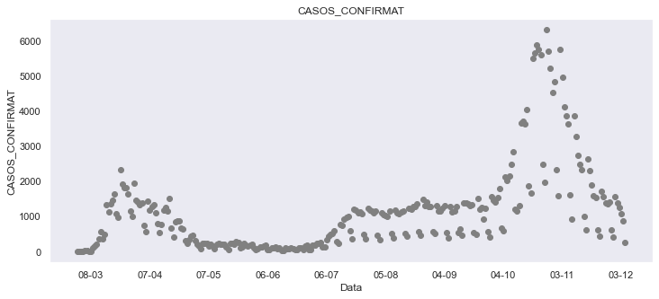

```python
scatter_plot_days('CASOS_CONFIRMAT',data,30)
```

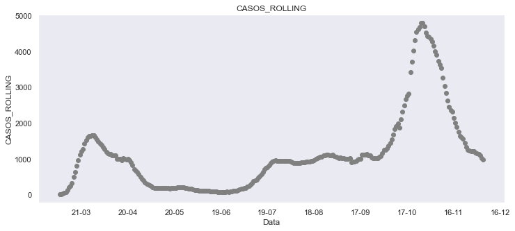

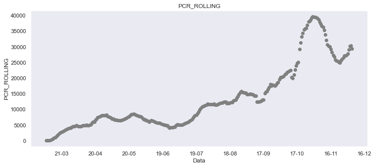

```python
scatter_plot_days('CASOS_ROLLING',data,30)
data['PCR_ROLLING'] = data['PCR'].rolling(window=rolling_average_days).mean()
scatter_plot_days('PCR_ROLLING',data,30)
```

We will also define other variables to identify the state of the pandemy:

- Positivity rate: percentage of positive PCR test.

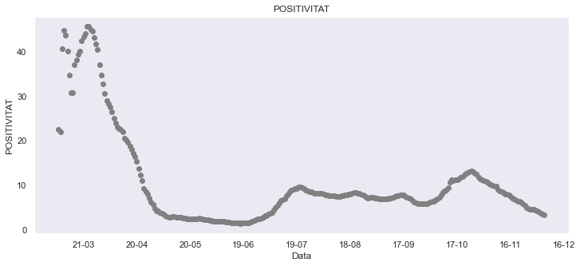

```python
data['POSITIVITAT'] = ((data["CASOS_ROLLING"])/(data["PCR_ROLLING"])*100)
scatter_plot_days('POSITIVITAT',data,30)
```

- We can clearly see the two waves: one until June and the second from September until now.
- The number of PCR tests has increased: in what we have defined as first wave, the number of PCR tests is not significative. We should remember that by those days Covid19 positives were considered those who had symptoms because there were not enough tests. This is what explains the high positivity rate of the first months (only severe cases were tested).

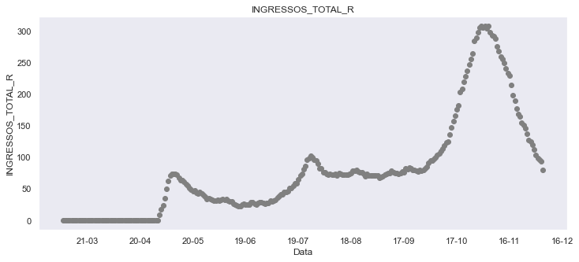

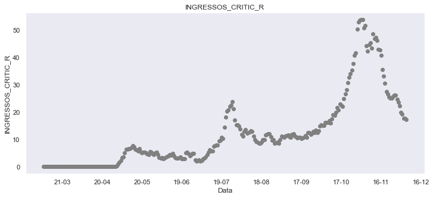

```python
data['INGRESSOS_TOTAL_R'] = data['INGRESSOS_TOTAL'].rolling(window=rolling_average_days).mean()
scatter_plot_days('INGRESSOS_TOTAL_R',data,30)
data['INGRESSOS_CRITIC_R'] = data['INGRESSOS_CRITIC'].rolling(window=rolling_average_days).mean()
scatter_plot_days('INGRESSOS_CRITIC_R',data,30)
```

- We do not have information of the hospital admissions during the first quarter of the year.

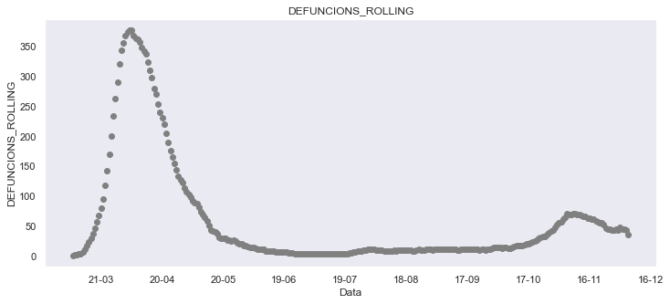

```python
data['DEFUNCIONS_ROLLING'] = data['DEFUNCIONS'].rolling(window=rolling_average_days).mean()
scatter_plot_days('DEFUNCIONS_ROLLING',data,30)
```

About the number of deaths: the first wave of the pandemic caused more deaths. In the correlation matrix we can see that the number of positive cases is closely related with PCR tests and the hospitals admissions.

```python
corr =data.corr().style.background_gradient(cmap='coolwarm').set_precision(2)
corr
```

|  | CASOS_CONFIRMAT | PCR | INGRESSOS_TOTAL | INGRESSOS_CRITIC | INGRESSATS_CRITIC | INGRESSATS_TOTAL | DEFUNCIONS | CASOS_ROLLING | PCR_ROLLING | POSITIVITAT | INGRESSOS_TOTAL_R | INGRESSOS_CRITIC_R | DEFUNCIONS_ROLLING |
| --- | --- | --- | --- | --- | --- | --- | --- | --- | --- | --- | --- | --- | --- |
| CASOS_CONFIRMAT | 1.00 | 0.83 | 0.82 | 0.75 | 0.44 | 0.51 | 0.11 | 0.88 | 0.71 | 0.18 | 0.71 | 0.67 | 0.04 |
| PCR | 0.83 | 1.00 | 0.86 | 0.82 | 0.64 | 0.68 | -0.15 | 0.71 | 0.83 | -0.19 | 0.77 | 0.76 | -0.17 |
| INGRESSOS_TOTAL | 0.82 | 0.86 | 1.00 | 0.93 | 0.77 | 0.83 | -0.24 | 0.85 | 0.90 | -0.22 | 0.96 | 0.92 | -0.27 |
| INGRESSOS_CRITIC | 0.75 | 0.82 | 0.93 | 1.00 | 0.72 | 0.77 | -0.21 | 0.79 | 0.86 | -0.19 | 0.90 | 0.90 | -0.24 |
| INGRESSATS_CRITIC | 0.44 | 0.64 | 0.77 | 0.72 | 1.00 | 0.99 | -0.20 | 0.56 | 0.81 | -0.35 | 0.82 | 0.81 | -0.20 |
| INGRESSATS_TOTAL | 0.51 | 0.68 | 0.83 | 0.77 | 0.99 | 1.00 | -0.22 | 0.64 | 0.85 | -0.34 | 0.88 | 0.86 | -0.22 |
| DEFUNCIONS | 0.11 | -0.15 | -0.24 | -0.21 | -0.20 | -0.22 | 1.00 | 0.14 | -0.20 | 0.63 | -0.26 | -0.24 | 0.97 |
| CASOS_ROLLING | 0.88 | 0.71 | 0.85 | 0.79 | 0.56 | 0.64 | 0.14 | 1.00 | 0.84 | 0.16 | 0.85 | 0.82 | 0.10 |
| PCR_ROLLING | 0.71 | 0.83 | 0.90 | 0.86 | 0.81 | 0.85 | -0.20 | 0.84 | 1.00 | -0.25 | 0.94 | 0.93 | -0.20 |
| POSITIVITAT | 0.18 | -0.19 | -0.22 | -0.19 | -0.35 | -0.34 | 0.63 | 0.16 | -0.25 | 1.00 | -0.24 | -0.21 | 0.51 |
| INGRESSOS_TOTAL_R | 0.71 | 0.77 | 0.96 | 0.90 | 0.82 | 0.88 | -0.26 | 0.85 | 0.94 | -0.24 | 1.00 | 0.98 | -0.27 |
| INGRESSOS_CRITIC_R | 0.67 | 0.76 | 0.92 | 0.90 | 0.81 | 0.86 | -0.24 | 0.82 | 0.93 | -0.21 | 0.98 | 1.00 | -0.24 |
| DEFUNCIONS_ROLLING | 0.04 | -0.17 | -0.27 | -0.24 | -0.20 | -0.22 | 0.97 | 0.10 | -0.20 | 0.51 | -0.27 | -0.24 | 1.00 |

## 2. UNDERSTANDING THE FIRST WAVE

We consider the first wave the first 3 months of the pandemic situation.

We will explore the distribution of the variables in the dataset.

```python
df1 = data.copy()
```

```python
corr = df1.corr().style.background_gradient(cmap='coolwarm').set_precision(2)
corr
```

|  | CASOS_CONFIRMAT | PCR | INGRESSOS_TOTAL | INGRESSOS_CRITIC | INGRESSATS_CRITIC | INGRESSATS_TOTAL | DEFUNCIONS | CASOS_ROLLING | PCR_ROLLING | POSITIVITAT | INGRESSOS_TOTAL_R | INGRESSOS_CRITIC_R | DEFUNCIONS_ROLLING |
| --- | --- | --- | --- | --- | --- | --- | --- | --- | --- | --- | --- | --- | --- |
| CASOS_CONFIRMAT | 1.00 | 0.83 | 0.82 | 0.75 | 0.44 | 0.51 | 0.11 | 0.88 | 0.71 | 0.18 | 0.71 | 0.67 | 0.04 |
| PCR | 0.83 | 1.00 | 0.86 | 0.82 | 0.64 | 0.68 | -0.15 | 0.71 | 0.83 | -0.19 | 0.77 | 0.76 | -0.17 |
| INGRESSOS_TOTAL | 0.82 | 0.86 | 1.00 | 0.93 | 0.77 | 0.83 | -0.24 | 0.85 | 0.90 | -0.22 | 0.96 | 0.92 | -0.27 |
| INGRESSOS_CRITIC | 0.75 | 0.82 | 0.93 | 1.00 | 0.72 | 0.77 | -0.21 | 0.79 | 0.86 | -0.19 | 0.90 | 0.90 | -0.24 |
| INGRESSATS_CRITIC | 0.44 | 0.64 | 0.77 | 0.72 | 1.00 | 0.99 | -0.20 | 0.56 | 0.81 | -0.35 | 0.82 | 0.81 | -0.20 |
| INGRESSATS_TOTAL | 0.51 | 0.68 | 0.83 | 0.77 | 0.99 | 1.00 | -0.22 | 0.64 | 0.85 | -0.34 | 0.88 | 0.86 | -0.22 |
| DEFUNCIONS | 0.11 | -0.15 | -0.24 | -0.21 | -0.20 | -0.22 | 1.00 | 0.14 | -0.20 | 0.63 | -0.26 | -0.24 | 0.97 |
| CASOS_ROLLING | 0.88 | 0.71 | 0.85 | 0.79 | 0.56 | 0.64 | 0.14 | 1.00 | 0.84 | 0.16 | 0.85 | 0.82 | 0.10 |
| PCR_ROLLING | 0.71 | 0.83 | 0.90 | 0.86 | 0.81 | 0.85 | -0.20 | 0.84 | 1.00 | -0.25 | 0.94 | 0.93 | -0.20 |
| POSITIVITAT | 0.18 | -0.19 | -0.22 | -0.19 | -0.35 | -0.34 | 0.63 | 0.16 | -0.25 | 1.00 | -0.24 | -0.21 | 0.51 |
| INGRESSOS_TOTAL_R | 0.71 | 0.77 | 0.96 | 0.90 | 0.82 | 0.88 | -0.26 | 0.85 | 0.94 | -0.24 | 1.00 | 0.98 | -0.27 |
| INGRESSOS_CRITIC_R | 0.67 | 0.76 | 0.92 | 0.90 | 0.81 | 0.86 | -0.24 | 0.82 | 0.93 | -0.21 | 0.98 | 1.00 | -0.24 |
| DEFUNCIONS_ROLLING | 0.04 | -0.17 | -0.27 | -0.24 | -0.20 | -0.22 | 0.97 | 0.10 | -0.20 | 0.51 | -0.27 | -0.24 | 1.00 |

```python
#we consider the first 3 months of the pandemic first wave
df1 = data[(data['DATA'] >= '2020-3-1') & (data['DATA'] <= '2020-6-1')]
df1 = df1.reset_index()
df1.head(4)
```

|  | index | DATA | CASOS_CONFIRMAT | PCR | INGRESSOS_TOTAL | INGRESSOS_CRITIC | INGRESSATS_CRITIC | INGRESSATS_TOTAL | DEFUNCIONS | CASOS_ROLLING | PCR_ROLLING | POSITIVITAT | INGRESSOS_TOTAL_R | INGRESSOS_CRITIC_R | DEFUNCIONS_ROLLING |
| --- | --- | --- | --- | --- | --- | --- | --- | --- | --- | --- | --- | --- | --- | --- | --- |
| 0 | 0 | 2020-03-01 | 1 | 20 | 0 | 0 | 0 | 0 | 0 | NaN | NaN | NaN | NaN | NaN | NaN |
| 1 | 1 | 2020-03-02 | 4 | 34 | 0 | 0 | 0 | 0 | 0 | NaN | NaN | NaN | NaN | NaN | NaN |
| 2 | 2 | 2020-03-03 | 9 | 25 | 0 | 0 | 0 | 0 | 0 | NaN | NaN | NaN | NaN | NaN | NaN |
| 3 | 3 | 2020-03-04 | 7 | 29 | 0 | 0 | 0 | 0 | 0 | NaN | NaN | NaN | NaN | NaN | NaN |

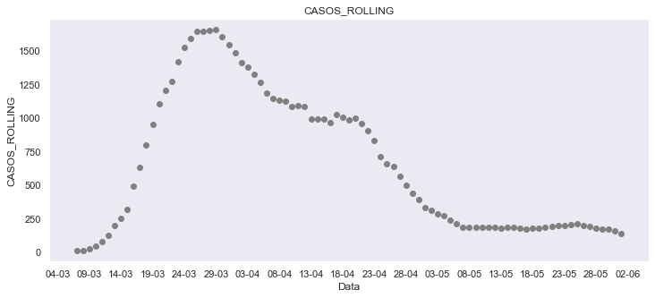

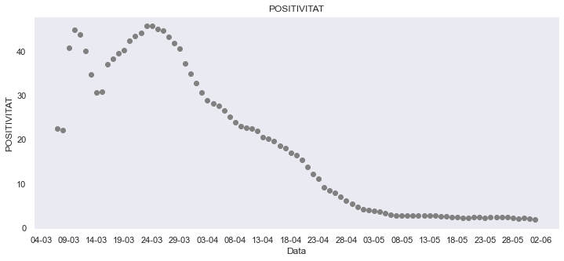

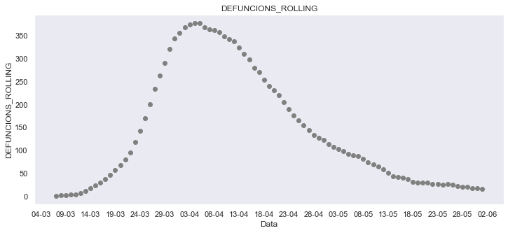

```python
scatter_plot_days('CASOS_ROLLING',df1,5)
scatter_plot_days('POSITIVITAT',df1,5)
scatter_plot_days('DEFUNCIONS_ROLLING',df1,5)
```

We see that 'DEFUNCIONS','POSITIVITAT' and 'NUMCASOS' have similar distributions, therefore we will construct a new derived variable to estimate the pandemic progression.

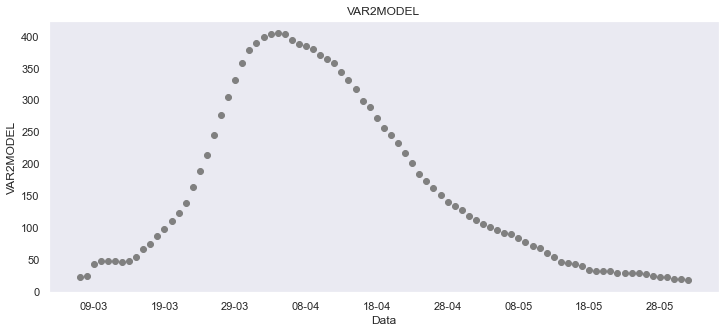

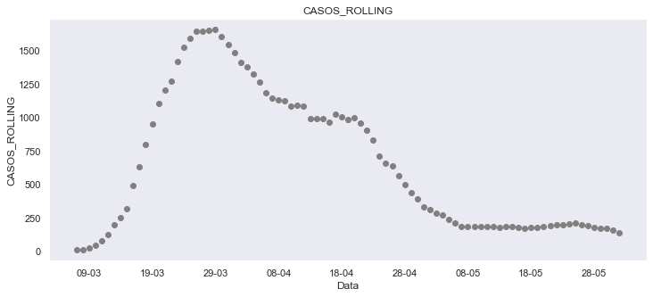

```python
df1['VAR2MODEL'] = df1['POSITIVITAT'] + df1['DEFUNCIONS_ROLLING']
scatter_plot_days('VAR2MODEL',df1,10)
scatter_plot_days('CASOS_ROLLING',df1,10)
```

With the derived variable we will train a liner regression to predict when the deaths and the positivity rate will become 0. For this, we will use the cases after the peak.

### 2.1 Building a linear model

```python
def linear_regression_cov(data, var,days_forward,intervalplot):
    # # let's train our model only with data after the peak
    peak = data[var].idxmax()
    X_train = [[i] for i in range(peak,len(data[var])-1)] #days after the peak
    y = data[var].tolist()[1:]
    y_train = y[peak:]

    model = linear_model.LinearRegression()
    # Train the model using the training sets
    model.fit(X_train, y_train)
    print ("Linear Regression Model Score: " + str(model.score(X_train, y_train)))
    y_pred = model.predict(X_train)
    error = max_error(y_train, y_pred)
    X_test = [[i] for i in range(peak,peak+days_forward)]
    y_pred = model.predict(X_test)

    #boundaries with the error
    y_pred_max = []
    y_pred_min = []
    for i in range(0, len(y_pred)):
        y_pred_max.append(y_pred[i] + error)
        y_pred_min.append(y_pred[i] - error)

    #data info to plot
    d =str(data[data[var].idxmax() == data.index].DATA.values[0])
    date_zero = datetime.datetime.strptime(d[:10],'%Y-%m-%d')
    date_prev = []
    x_ticks = []
    step = 5
    data_curr = date_zero
    x_current = peak
    n = int(days_forward / step)
    for i in range(0, n + intervalplot):
        date_prev.append(str(data_curr.day) + "/" + str(data_curr.month))
        x_ticks.append(x_current)
        data_curr = data_curr + timedelta(days=step)
        x_current = x_current + step

    plt.grid()
    plt.scatter(X_train, y_train,c = 'lightblue',label = "Derived Variable")
    # plot linear regression prediction
    plt.plot(X_test, y_pred, color='blue', linewidth=2, label = 'Predicted')
    # plot maximum error
    plt.plot(X_test, y_pred_max, color='gray', linewidth=1, linestyle='dashed')
    #plot minimum error
    plt.plot(X_test, y_pred_min, color='gray', linewidth=1, linestyle='dashed')

    plt.xlabel('Days')
    plt.xlim(peak, peak + days_forward)
    plt.xticks(x_ticks, date_prev)

    plt.ylabel(var)
    plt.yscale("log")
    plt.legend()
    plt.show()
```

We build X_test with the number of days forward we want our model to predict (remember that the once the number of cases peaked in March, until end of May the curve of cases did not decrease, so at least two months!).

## 2.2 Plotting results

```
Linear Regression Model Score: 0.9084701302604914
```

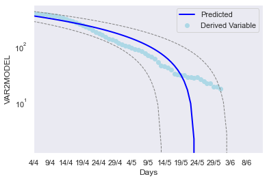

```python
linear_regression_cov(df1, 'VAR2MODEL',days_forward = 70,intervalplot = 0)
```

Our model predicts that the first wave ends by the end of May: between the 14th of May and 3rd of June.

```python
df2 = data.copy()
```

```python
df2 = data[(data['DATA'] >= '2020-9-1')]
df2 = df2.reset_index()
df2.head(4)
```

|  | index | DATA | CASOS_CONFIRMAT | PCR | INGRESSOS_TOTAL | INGRESSOS_CRITIC | INGRESSATS_CRITIC | INGRESSATS_TOTAL | DEFUNCIONS | CASOS_ROLLING | PCR_ROLLING | POSITIVITAT | INGRESSOS_TOTAL_R | INGRESSOS_CRITIC_R | DEFUNCIONS_ROLLING |
| --- | --- | --- | --- | --- | --- | --- | --- | --- | --- | --- | --- | --- | --- | --- | --- |
| 0 | 184 | 2020-09-01 | 1147 | 19952 | 75 | 15 | 118 | 682 | 15 | 1061.142857 | 15211.142857 | 6.976089 | 70.714286 | 9.714286 | 10.428571 |
| 1 | 185 | 2020-09-02 | 1157 | 17522 | 73 | 14 | 122 | 651 | 9 | 1027.000000 | 14797.571429 | 6.940328 | 71.142857 | 11.142857 | 10.285714 |
| 2 | 186 | 2020-09-03 | 1225 | 18611 | 61 | 7 | 120 | 636 | 13 | 1021.571429 | 14830.571429 | 6.888281 | 67.142857 | 10.857143 | 10.428571 |
| 3 | 187 | 2020-09-04 | 1308 | 20726 | 83 | 9 | 118 | 636 | 12 | 1027.285714 | 14842.857143 | 6.921078 | 69.000000 | 10.714286 | 10.571429 |

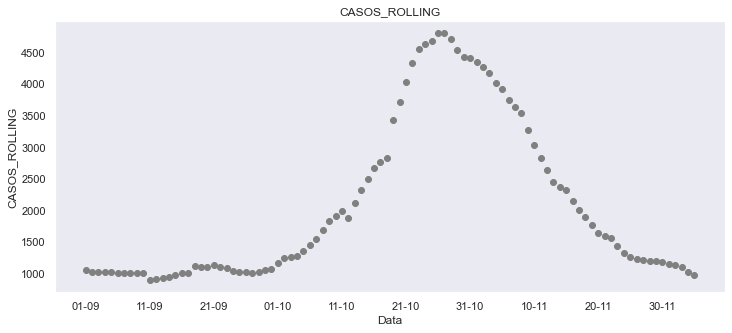

```python
scatter_plot_days('CASOS_ROLLING',df2,10)
```

As before, we should check which variables have a similar distribution. This time, we could choose 'DEFUNCIONS', 'INGRESSOS_TOTAL', 'PCR' or 'INGRESSOS_CRITICS'. After some tests:

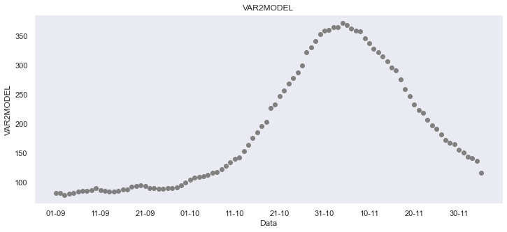

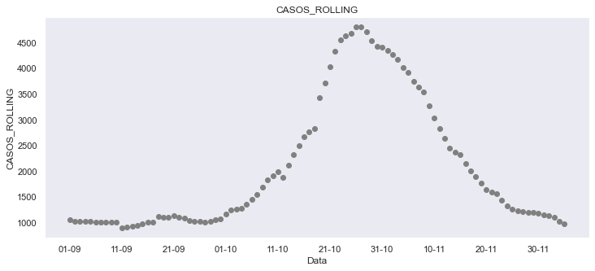

```python
#df2['VAR2MODEL'] = df2['INGRESSOS_TOTAL_R'] + df2['INGRESSOS_CRITIC']
df2['VAR2MODEL'] = df2['INGRESSOS_TOTAL_R'] + df2['DEFUNCIONS_ROLLING']
scatter_plot_days('VAR2MODEL',df2,10)
scatter_plot_days('CASOS_ROLLING',df2,10)
```

```
Linear Regression Model Score: 0.9895534362417981
```

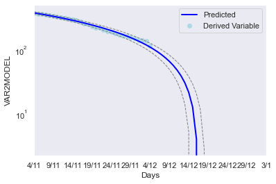

```python
linear_regression_cov(df2, 'VAR2MODEL',days_forward = 60,intervalplot = 1)
```

The data was last updated on 6th December. We should remember that by this week measures of contention were relaxed and we have to understand this prediction as if we had remained in the same contained scenario.

Our model predicts that this second wave could have "finished" by the 15th December. We have also learned that this second wave is less deathly than the first, that the rate of PCR tests has increased and therefore the positivity has decreased (more people tested). It would be interesting to compare the hospitals admissions and the number of patients that needed ICU beds, but we do not have this information for the first wave in this dataset.

## 3. SIR MODEL

The SIR model describes the evolution of an epidemic labeling the population into three groups:

- Susceptible: Population that can get infected.
- Infectious: Population infected at a time t.
- Recovered: Population that has recovered and has a supposed immunity (we will suppose that for Covid there is a 3 months immunity, even though this is not proven).

The flow of the epidemic is understood as follows:

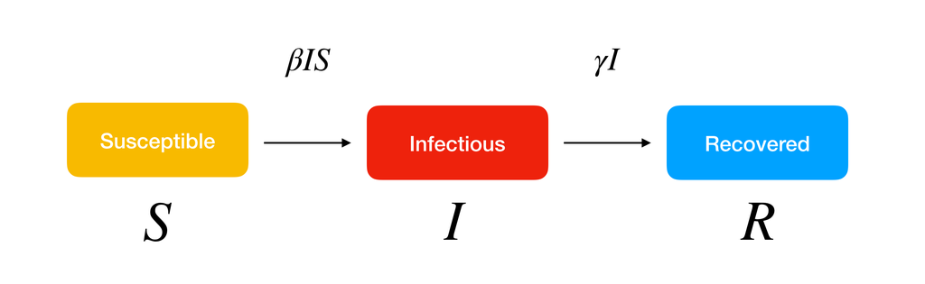

### 3.1 Differential equations for SIR model

We define the SIR differential equations as follows:

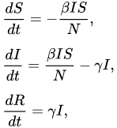

```python
def SIR(x, t, beta, gamma):
    s, i, r = x
    dsdt = -beta * s * i
    didt = beta * s * i - gamma * i
    drdt =  gamma * i
    return [dsdt, didt, drdt]
```

### 3.2 Estimating parameters

The main parameters of the SIR model are the basic reproduction number R0, the rate of recovery γ and the transmission rate β. With this we can model the evolution t days forward.

- R0: basic reproduction number, rate of infection. Measures the amount of people an infected individual can infect. To have the pandemic under control it should be < 1.
- γ: rate of recovery of infections. The inverse of the time it takes for an individual to overcome the infection. For the covid-19 we suppose 6-7 days.
- β: transmission rate. Computed by the product of the rate of infection and the rate of recovery measures the new infections.

As for the active cases, we will sum the cases in the last 7 days and when the data was last updated, the R0 was 0.98 and in a positive trend. We will make some tests to see what can happen with different values of R0.

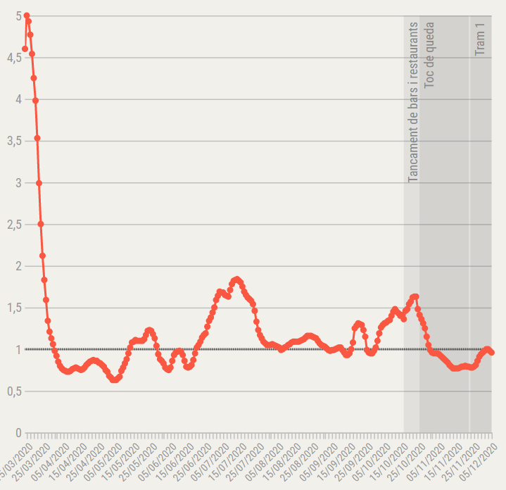

```python
infected = data[data.DATA >= str(date(2020,11,29))] #last 7 days
healed = data[data.DATA < str(date(2020,11,28))]
healed=  healed[healed.DATA >= str(date(2020,9,28))] #we suppose that there is a 3 month immunity

##computing the number of infected
activeCases = infected.CASOS_CONFIRMAT.sum()
cases = healed.CASOS_CONFIRMAT.sum()

population = 7.566*10**6 #set population
```

```python
def setSIRparameters(R0,infective_days,days_forward):

    # initial S,I,R
    i_initial = activeCases / population #initial infected
    r_initial = cases / population#0  #people who has already been infected (recovered)
    s_initial = 1 - i_initial - r_initial

    #set parameters
    gamma = 1/infective_days #rate of recovery
    beta = R0*gamma #transmission rate

    #set time parameters
    t = np.linspace(0, days_forward, 2000)

    return beta, gamma, i_initial,r_initial,s_initial,t
```

### 3.3 Plotting the results for different values of R0.

We define two functions to plot the output of the SIR model.

```python
#plots the susceptible, the infected and the recovered for a time t
def plotSIR(t,sirmodel):
    S, I, R = sirmodel.T

    fig = plt.figure(facecolor='w')

    ax = fig.add_subplot(111, axisbelow=True)

    ax.plot(t, S, 'b', alpha=0.5, lw=2, label='Susceptible')
    ax.plot(t, I ,'r', alpha=0.5, lw=2, label='Infected')
    ax.plot(t, R, 'g', alpha=0.5, lw=2, label='Recovered')

    ax.set_xlabel('Time in days')
    ax.set_ylabel('Population in percentage')
    legend = ax.legend()

    plt.title("SIR Model")
    plt.show()
```

```python
#plots the infected
def plotInfected(i):
    fig = plt.figure(facecolor='w')

    ax = fig.add_subplot(111, axisbelow=True)

    ax.plot(t, i ,'r', alpha=0.5, lw=2, label='Infected')

    ax.set_xlabel('Time in days')
    ax.set_ylabel('Population in percentage')
    legend = ax.legend()

    plt.title("Infected population")
    plt.show()
```

### 3.3.1 R0 maintains a value < 1, R0=0.98

In this scenario, we are decreasing the positive cases and "controlling the epidemic. It is a danger zone because it is too close to 1 and the trend can easily change.

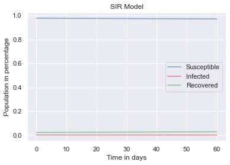

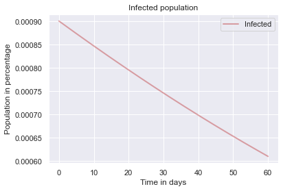

```python
b, g,i_0,r_0,s_0,t = setSIRparameters(R0 = 0.98,infective_days= 7,days_forward = 60)
#initial conditions
x_initial =  s_0,i_0,r_0
sirmodel = odeint(SIR, x_initial, t, args=(b, g))
#plot s,i,r
plotSIR(t,sirmodel)
#plot infected
s, i, r = sirmodel.T
plotInfected(i)
```

### 3.3.2 R0 increases to 1.1

Just increasing a bit R0 we see a much more different scenario: positive cases start to rise and it would take almost a year to stabilize the situation.

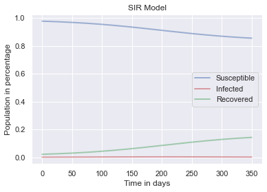

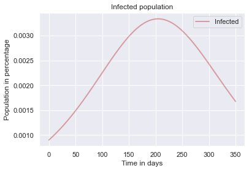

```python
b, g,i_0,r_0,s_0,t = setSIRparameters(R0 = 1.1,infective_days= 7,days_forward = 350)
x_initial =  s_0,i_0,r_0
sirmodel = odeint(SIR, x_initial, t, args=(b, g))

#plot s,i,r
plotSIR(t,sirmodel)

#plot infected
s, i, r = sirmodel.T
plotInfected(i)
```

### 3.3.3 R0 increases to 2

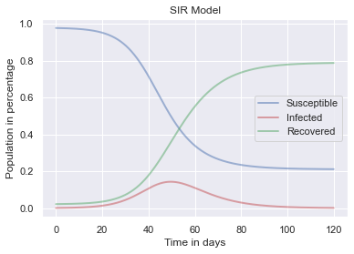

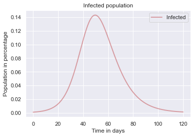

```python
b, g,i_0,r_0,s_0,t = setSIRparameters(R0 = 2,infective_days= 7,days_forward = 120)
x_initial =  s_0,i_0,r_0
sirmodel = odeint(SIR, x_initial, t, args=(b, g))

#plot s,i,r
plotSIR(t,sirmodel)

#plot infected
s, i, r = sirmodel.T
plotInfected(i)
```

## 4. CONCLUSIONS

1. About the data:
   - Increasing the testing helps in the contention of the pandemic, positivity helps predicting the number of cases.
   - It would be useful to have the data of hospitals admissions during the first wave, since it is a relevant information for the second wave.
   - Measures such as social distancing and closing restauration does have an effect in the pandemic evolution.
1. About the Linear model:
   - It predicts well the end of the first wave and it is useful to predict the behaviour of the evolution of the pandemic.
   - Probably, if all measures had remained intact in December, the number of cases would have decreased by 15th December.
1. About the SIR model:
   - Social distancing is probably the most efficient measure to contain the pandemic: when the R0 decreases fast so does the number of new positives.
   - It is dangerous to have the R0 over 1.

# 5. REFERENCES

https://towardsdatascience.com/insights-to-modeling-covid-19-epidemic-using-new-labels-4dee6d493e29

https://www.kaggle.com/lisphilar/covid-19-data-with-sir-model

https://medium.com/@angelica.loduca/predicting-the-end-of-the-coronavirus-epidemics-in-italy-8da9811f7740